# Importing data from YAML file to R

Taha Ahmed

2025-05-25

The aim here should be to read the YAML data into an R tibble `periodicdata`.

## Reading the YAML data

We can use the `yaml::read_yaml()` function to ingest the YAML file.

```r
# imported YAML data (list of lists of lists)
# read_yaml() uses the YAML parser provided by libyaml, which conforms to the YAML 1.1 specification
pd_yaml <- yaml::read_yaml(
   file = yaml_path,
   # we want as.named.list = TRUE, otherwise we lose the property names
   as.named.list = TRUE, # TRUE is default
   merge.warning = FALSE, # FALSE is default
   # merge.precedence has no effect for this dataset, as far as I can tell
   merge.precedence = "order") # "order" is default, else "override"
```

For starters, let’s list all elemental properties that make up the *periodic data*:

```r
pd_yaml |> summary()
```

```
##                                Length Class  Mode
## Symbol                         2      -none- list
## Name                           3      -none- list
## Atomic_Number                  3      -none- list
## Atomic_Weight                  5      -none- list
## Standard_Atomic_Weight         8      -none- list
## Conventional_Atomic_Weight     6      -none- list
## Density                        6      -none- list
## Melting_Point                  4      -none- list
## Boiling_Point                  4      -none- list
## Phase                          2      -none- list
## Critical_Pressure              5      -none- list
## Critical_Temperature           5      -none- list
## Heat_of_Fusion                 3      -none- list
## Heat_of_Vapourization          3      -none- list
## Specific_Heat_Capacity         7      -none- list
## Adiabatic_Index                4      -none- list
## Neel_Point                     5      -none- list
## Thermal_Conductivity           5      -none- list
## Thermal_Expansion              4      -none- list
## Density_Liquid                 6      -none- list
## Molar_Volume                   4      -none- list
## Brinell_Hardness               5      -none- list
## Mohs_Hardness                  4      -none- list
## Vickers_Hardness               4      -none- list
## Bulk_Modulus                   4      -none- list
## Shear_Modulus                  4      -none- list
## Young_Modulus                  4      -none- list
## Poisson_Ratio                  4      -none- list
## Refractive_Index               4      -none- list
## Speed_of_Sound                 3      -none- list
## Valence                        2      -none- list
## Electronegativity              4      -none- list
## Electron_Affinity              5      -none- list
## DOT_Hazard_Class               3      -none- list
## DOT_Numbers                    2      -none- list
## RTECS_Number                   3      -none- list
## Block                          2      -none- list
## Group                          3      -none- list
## Period                         3      -none- list
```

[output cut: 26 more lines]

```
## Space_Group_Number             2      -none- list
## Half_Life                      4      -none- list
## Lifetime                       4      -none- list
## Decay_Mode                     2      -none- list
## Quantum_Numbers                2      -none- list
## Neutron_Cross_Section          2      -none- list
## Neutron_Mass_Absorption        2      -none- list
## Autoignition_Point             3      -none- list
## Heat_of_Combustion             3      -none- list
## Gmelin_Number                  2      -none- list
## Production_2010                4      -none- list
## Price_2010                     4      -none- list
## Element_Descriptions           4      -none- list
## XKCD_Four_Elements             4      -none- list
## Natural_Occurrence             4      -none- list
```

Now we need to do some wrangling to get this R list into a shape we can work with, primarily in order to rectangularize it and make it into one or more tibbles.

We can use `tidyr::unnest_longer()` to convert a list of named 1-element lists to a two column tibble.

```r
# create a list of tibbles, where each tibble holds a property and the following fields
# (only "value" or those with length == 1 to ensure they can be recycled)
pdl_fields <- c("title", "title_symbol", "unit", "description", "footnote", "value")
# this list is also named with each property from the get-go
# https://stackoverflow.com/a/35035142/1198249
# Periodic Data List of tibbles
pdl <- setNames(vector("list", length = length(pd_yaml)), names(pd_yaml))
# The "note" field cannot be expected to have the same number of rows as "value",
# so to make my life easier we will import that into a separate variable
pdl_note <- setNames(vector("list", length = length(pd_yaml)), names(pd_yaml))
for (p in 1:length(pd_yaml)) {
   pdl[[p]] <-
      pd_yaml[[p]][names(pd_yaml[[p]]) %in% pdl_fields] %>%
      tibble::as_tibble() %>%
      # https://tidyr.tidyverse.org/reference/unnest_longer.html
      tidyr::unnest_longer(col = value, indices_to = "Symbol") %>%
      # note that this "value" column automatically gets an attribute "names"
      # which is redundant since we have the "symbol" column. Get rid of it.
      # To drop attributes from all columns at once: mutate(across(everything(), as.vector))
      mutate(value = as.vector(value))
   # now let's take care of the "note" field
   if (any(names(pd_yaml[[p]]) %in% c("note"))) {
      pdl_note[[p]] <-
         pd_yaml[[p]][names(pd_yaml[[p]]) %in% c("note")] %>%
         tibble::as_tibble() %>%
         tidyr::unnest_longer(col = note, indices_to = "Symbol")
      # now we can easily put "note" into place in each tibble
      # by joining by "symbol" we ensure that each note goes on the correct element's row
      pdl[[p]] <- left_join(pdl[[p]], pdl_note[[p]], by = "Symbol")
   }
}
# at this point we no longer need the pdl_note list - all its data is incorporated
# in the tibbles of pdl
# print three random tibbles from the list (poor man's quality control)
pdl[sample(1:length(pdl), 3)]
```

```
## $Space_Group_Number
## # A tibble: 118 × 3
##    title              value Symbol
##    <chr>              <int> <chr>
##  1 Space group number   194 H
##  2 Space group number   225 He
##  3 Space group number   229 Li
##  4 Space group number   194 Be
##  5 Space group number   166 B
##  6 Space group number   194 C
##  7 Space group number   194 N
##  8 Space group number    12 O
##  9 Space group number    15 F
## 10 Space group number   225 Ne
## # ℹ 108 more rows
##
## $Gas_Phase_Configuration
## # A tibble: 118 × 3
##    title                      value        Symbol
##    <chr>                      <chr>        <chr>
##  1 Configuration in gas phase "Diatomic"   H
##  2 Configuration in gas phase "Monoatomic" He
##  3 Configuration in gas phase ""           Li
##  4 Configuration in gas phase ""           Be
##  5 Configuration in gas phase ""           B
##  6 Configuration in gas phase ""           C
##  7 Configuration in gas phase "Diatomic"   N
##  8 Configuration in gas phase "Diatomic"   O
##  9 Configuration in gas phase "Diatomic"   F
## 10 Configuration in gas phase "Monoatomic" Ne
## # ℹ 108 more rows
##
## $Name
## # A tibble: 118 × 4
##    title footnote                                value     Symbol
##    <chr> <chr>                                   <chr>     <chr>
##  1 Name  "Using IUPAC spelling for Al, P, Cs.\n" Hydrogen  H
##  2 Name  "Using IUPAC spelling for Al, P, Cs.\n" Helium    He
##  3 Name  "Using IUPAC spelling for Al, P, Cs.\n" Lithium   Li
##  4 Name  "Using IUPAC spelling for Al, P, Cs.\n" Beryllium Be
##  5 Name  "Using IUPAC spelling for Al, P, Cs.\n" Boron     B
##  6 Name  "Using IUPAC spelling for Al, P, Cs.\n" Carbon    C
##  7 Name  "Using IUPAC spelling for Al, P, Cs.\n" Nitrogen  N
##  8 Name  "Using IUPAC spelling for Al, P, Cs.\n" Oxygen    O
##  9 Name  "Using IUPAC spelling for Al, P, Cs.\n" Fluorine  F
## 10 Name  "Using IUPAC spelling for Al, P, Cs.\n" Neon      Ne
## # ℹ 108 more rows
```

So now we have a list that contains a tibble for each property. All the property tibbles use the elemental `Symbol` as the unique column.

The `reference` dict needs special consideration. Because it can be a list of arbitrary length with each element being a dict of multiple named elements (`url`, `doi`, `citation`, possibly others), stuffing this jumble into a tibble column seems would likely render it data unusable anyway.

What if we instead put the `reference` data into an attribute of the tibble?

- https://stackoverflow.com/questions/48157225/how-to-add-metadata-to-a-tibble

I considered using `comment` instead of `attribute`, because the latter requires us to explicitly state the name of the attribute. And I only expect `reference` to be attached to the tibble in this manner, so let’s save on some typing for everyone involved? I would have preferred to use `comment`, but unfortunalely `comment` only works with *character vectors*, and so cannot support our lists.

```r
for (p in 1:length(pd_yaml)) {
   if (any(names(pd_yaml[[p]]) %in% c("reference"))) {
      attr(pdl[[p]], "reference") <-
         pd_yaml[[p]][names(pd_yaml[[p]]) %in% c("reference")]$reference
   }
}
```

Note that `attribute`s are not printed when printing the tibble - to see it you have to explicitly call `attr()`, for example:

```r
pdl$Production_2010 |> attr("reference")
```

```
## [[1]]
## [[1]]$doi
## [1] "https://doi.org/10.1039/C2RA20839C"
##
## [[1]]$citation
## [1] "Peter C. K. Vesborg and Thomas F. Jaramillo. “Addressing the terawatt challenge: scalability in the supply of chemical elements for renewable energy”. RSC Advances 2.21 (2012), pp. 7933-7947.\n"
```

## Joining `value` from all elemental properties into a wide-form tibble

What I am looking for is a tibble with 118 rows (column `symbol`) where each column is a property (for the moment without considering units). The name of the column should preferably be the name of the list element in `pdl` (because in contrast to the `title` column this name can be trusted to not contain spaces).

How will this tibble behave when we start introducing properties that have more than one value per element? Well, then we can simply let those columns be nested, and unnest on-demand if necessary. Feels like this approach should work.

I want to allow the YAML data to not necessarily include all known elements for every property (some properties are only defined for some elements, anyway).

> Why not a long-form tibble? `bind_rows()` would have been a good choice, but our data has a quirk: the same column name (`value` in this case) can have different type across properties, being character in one and numeric in another. This severely hampers *any* attempt to construct a long-form data frame.

```r
# First, we need something to join against, for this I chose Symbol which is
# a natural choice as the unique identifier in this dataset
# For the sake of consistency, use capitalized name for Symbol column
pdt <- tibble(Symbol = pdl$Symbol$value)
for (p in which(names(pdl) != "Symbol")) {
   pdt <- left_join(
      x = pdt,
      y = pdl[[p]] |>
         # discard all columns except $value
         select(value, Symbol) |>
         # value in column $title should be set as new name for column $value.
         # Turns out it is doable, but note the unusual syntax !! :=
         # https://stackoverflow.com/questions/45472480/how-to-rename-a-column-to-a-variable-name-in-a-tidyverse-way
         dplyr::rename(!!names(pdl)[p] := value),
      by = "Symbol")
}
```

Print a random selection of columns (to aid in error-checking while rebuilding the vignette). We randomly reshuffle the order of columns except for the first two, this way the info printed at the bottom of the tibble output still state the correct number of non-visible columns.

- https://statisticsglobe.com/randomly-reorder-data-frame-by-row-and-column-in-r#example-2-shuffle-data-frame-by-column

```r
pdt[, c(1, 2, sample(3:ncol(pdt)))]
```

```
## # A tibble: 118 × 80
##    Symbol Name      Shear_Modulus Half_Life DOT_Numbers Young_Modulus Atomic_Weight
##    <chr>  <chr>             <dbl>     <dbl> <chr>               <dbl>         <dbl>
##  1 H      Hydrogen             NA       Inf "1966"                 NA          1.01
##  2 He     Helium               NA       Inf "1963"                 NA          4.00
##  3 Li     Lithium      4200000000       Inf "1415"         4900000000          6.94
##  4 Be     Beryllium  132000000000       Inf "1567"       287000000000          9.01
##  5 B      Boron                NA       Inf ""                     NA         10.8
##  6 C      Carbon               NA       Inf "1361"                 NA         12.0
##  7 N      Nitrogen             NA       Inf "1977"                 NA         14.0
##  8 O      Oxygen               NA       Inf "1073"                 NA         16.0
##  9 F      Fluorine             NA       Inf "9192"                 NA         19.0
## 10 Ne     Neon                 NA       Inf "1913"                 NA         20.2
## # ℹ 108 more rows
## # ℹ 73 more variables: CID_Number <chr>, Colour <chr>, Thermal_Expansion <dbl>,
## #   Series <chr>, Gmelin_Number <chr>, Density <dbl>, Percent_in_Oceans <dbl>,
## #   Group <int>, Percent_in_Meteorites <dbl>, Group_Left_Step <int>,
## #   Molar_Volume <dbl>, Bulk_Modulus <dbl>, Heat_of_Combustion <int>, Block <chr>,
## #   Mohs_Hardness <dbl>, Space_Group_Number <int>, Phase <chr>,
## #   Percent_in_Sun <dbl>, Covalent_Radius <dbl>, CAS_Number <chr>, …
```

## The IUPAC periodic table

So let’s demonstrate how to put together a periodic table from this data. We will use ggplot2 for plotting, and first we will need to construct a new tibble built containing the elemental properties we require, namely, `Symbol`, `Name`, `Atomic_Number`, `Conventional_Atomic_Weight`, `Group`, `Period`, and `Series`.

```r
ptable_iupac <-
   pdt %>%
   select(Symbol, Name, Atomic_Number, Conventional_Atomic_Weight, Group, Period, Series) %>%
   # adjust vertical position for La and Ac periods *before* changing type to character
   # https://stackoverflow.com/questions/22337394/dplyr-mutate-with-conditional-values
   mutate(Period = case_when(
      # Atomic_Number >= 57 & Atomic_Number <= 71 ~ lanthanides.vpos,
      Series == "Lanthanide" ~ lanthanoids.vpos,
      # Atomic_Number >= 89 & Atomic_Number <= 103 ~ actinides.vpos,
      Series == "Actinide" ~ actinoids.vpos,
      TRUE ~ Period)) %>%
   mutate(Atomic_Number = as.character(Atomic_Number)) %>%
   # create two virtual elements as placeholders for the lanthanoids/lanthanoids labels
   tibble::add_row(
      Name = c("lanthanoids", "actinoids"),
      Group = c(3, 3),
      Period = c(6, 7),
      Atomic_Number = c("57-71", "89-103"),
      Series = c("Lanthanide", "Actinide"))
```

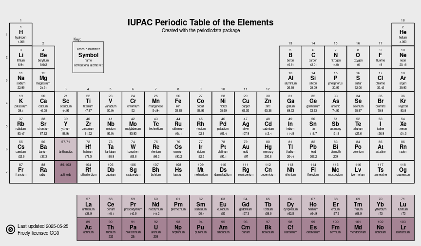

## Dynamically create a list of properties for the README

I want to include a table showing the properties in the README, which means we are limited to Markdown format.

| Property | Description (truncated) | DOI | URL |
| --- | --- | --- | --- |
| Adiabatic_Index | Adiabatic index, also known as the heat capacity ratio, the ratio of specific… |  | [1](https://periodictable.com/Properties/A/AdiabaticIndex.an.html), [2](https://en.wikipedia.org/wiki/Heat_capacity_ratio) |
| Atomic_Number | Atomic number |  | [1](https://en.wikipedia.org/wiki/Atomic_number) |
| Atomic_Radius | Atomic radius | [1](https://doi.org/10.1063/1.1712084) |  |
| Atomic_Weight | Atomic weight of the longest-lived isotope. |  | [1](https://www.britannica.com/science/atomic-weight) |
| Autoignition_Point | Autoignition point |  |  |
| Block | Block |  |  |
| Boiling_Point | Boiling point at STP |  |  |
| Brinell_Hardness | Brinell hardness |  | [1](https://en.wikipedia.org/wiki/Brinell_hardness_test), 2 |
| Bulk_Modulus | Bulk modulus |  |  |
| CAS_Number | CAS registry number |  | [1](https://en.wikipedia.org/wiki/CAS_Registry_Number) |
| CID_Number | CID number |  |  |
| Colour | Colour at STP |  |  |
| Conventional_Atomic_Weight | Standard atomic weight abridged to four significant digits, for uses where a … | [1](https://doi.org/10.1021/acs.jchemed.6b00510) |  |
| Covalent_Radius | Covalent radius |  |  |
| Critical_Pressure | Critical pressure |  | 1 |
| Critical_Temperature | Critical temperature |  | 1 |
| Curie_Temperature | Curie temperature |  | [1](https://en.wikipedia.org/wiki/Curie_temperature) |
| DOT_Hazard_Class | US DOT hazard class |  | [1](https://en.wikipedia.org/wiki/Dangerous_goods#United_States) |
| DOT_Numbers | US DOT number |  |  |
| Decay_Mode | Decay mode |  |  |
| Density | Density at STP |  | [1](https://periodictable.com/Properties/A/Density.html) |
| Density_Liquid | Density in the liquid state |  | [1](https://periodictable.com/Properties/A/LiquidDensity.an.html) |
| Electrical_Conductivity | Electrical conductivity |  |  |
| Electrical_Resistivity | Electrical resistivity |  |  |
| Electrical_Type | Electrical type |  |  |
| Electron_Affinity | Electron affinity |  | 1, [2](https://en.wikipedia.org/wiki/Electron_affinity) |
| Electron_Configuration | Electron configuration |  |  |
| Electronegativity | Electronegativity (Pauling) |  | [1](https://periodictable.com/Properties/A/Electronegativity.html), [2](https://en.wikipedia.org/wiki/Electronegativity#Pauling_electronegativity), [3](https://www.webelements.com/periodicity/eneg_pau… |
| Element_Descriptions | Element descriptions from the Debian dict-elements package v20001107-a-9.1. L… |  | [1](https://packages.debian.org/sid/all/dict-elements) |
| Gas_Phase_Configuration | Configuration in gas phase |  |  |
| Gmelin_Number | Gmelin number |  |  |
| Group | Group assignments per the IUPAC periodic table. |  |  |
| Group_Left_Step | Group assignments per the left step periodic table (Janet’s table). |  | 1 |
| Half_Life | Half-life |  |  |
| Heat_of_Combustion | Heat of combustion |  |  |
| Heat_of_Fusion | Heat of fusion |  |  |
| Heat_of_Vapourization | Heat of vapourization |  |  |
| Lifetime | Lifetime |  | [1](https://periodictable.com/Properties/A/Lifetime.html) |
| Magnetic_Susceptibility_Volume | Magnetic susceptibility by volume |  | [1](https://en.wikipedia.org/wiki/Magnetic_susceptibility#Volume_susceptibility) |
| Magnetic_Type | Magnetic type |  |  |
| Melting_Point | Melting point at STP |  |  |
| Mohs_Hardness | Mohs hardness |  | [1](https://en.wikipedia.org/wiki/Mohs_scale), 2 |
| Molar_Volume | Molar volume |  |  |
| Name | Name |  |  |
| Natural_Occurrence | Natural occurrence of the elements, whether primordial, from radioactive deca… |  | [1](https://en.wikipedia.org/wiki/Periodic_table#Structure), [2](https://en.wikipedia.org/wiki/Primordial_nuclide), [3](https://en.wikipedia.org/wiki/Trace_radioisotope), [4](https://en.wikipedia.org/… |
| Neel_Point | Neel point |  | [1](https://w.wiki/E9rs) |
| Neutron_Cross_Section | Neutron cross section |  |  |
| Neutron_Mass_Absorption | Neutron mass absorption |  |  |
| Percent_in_Earths_Crust | Percent in Earth’s crust |  |  |
| Percent_in_Humans | Percent in the human body |  |  |
| Percent_in_Meteorites | Percent in meteorites |  |  |
| Percent_in_Oceans | Percent in the Earth’s oceans |  |  |
| Percent_in_Sun | Percent in the Sun |  |  |
| Percent_in_Universe | Percent in the Universe |  |  |
| Period | Period assignments per the IUPAC periodic table. |  |  |
| Period_Left_Step | Period assignments per the left step periodic table (Janet’s table). |  |  |
| Phase | Phase at STP |  |  |
| Poisson_Ratio | Poisson’s ratio |  |  |
| Price_2010 | Price in 2010 | [1](https://doi.org/10.1039/C2RA20839C) |  |
| Production_2010 | Global primary production in 2010 | [1](https://doi.org/10.1039/C2RA20839C) |  |
| Quantum_Numbers | Quantum numbers |  |  |
| RTECS_Number | RTECS number |  | [1](https://en.wikipedia.org/wiki/Registry_of_Toxic_Effects_of_Chemical_Substances) |
| Refractive_Index | Refractive index |  |  |
| Series | Series per the IUPAC periodic table. |  |  |
| Shear_Modulus | Shear modulus |  |  |
| Space_Group_Name | Space group name |  |  |
| Space_Group_Name_LaTeX | Space group name |  |  |
| Space_Group_Number | Space group number |  |  |
| Specific_Heat_Capacity | The specific heat capacity, or the isobaric mass heat capacity. |  | [1](https://periodictable.com/Properties/A/SpecificHeat.html), [2](https://en.wikipedia.org/wiki/Table_of_specific_heat_capacities), [3](https://material-properties.org/specific-heat-capacity-of-chemi… |
| Speed_of_Sound | Speed of sound |  |  |
| Standard_Atomic_Weight | Standard atomic weight, or more correctly, standard relative atomic mass, is … | [1](https://doi.org/10.1515/pac-2019-0603), 2 | [1](https://www.ciaaw.org/atomic-weights.htm) |
| Superconducting_Point | Superconducting point |  |  |
| Symbol | Symbol |  |  |
| Thermal_Conductivity | Thermal conductivity |  | [1](https://en.wikipedia.org/wiki/List_of_thermal_conductivities) |
| Thermal_Expansion | Thermal expansion |  |  |
| Valence | Valence electrons |  |  |
| Van_der_Waals_Radius | Corresponds well to published vdW radii in literature. |  |  |
| Vickers_Hardness | Vickers hardness |  | 1 |
| XKCD_Four_Elements | Reproduction of XKCD #2975 published 2024-08-21. |  | [1](https://xkcd.com/2975), [2](https://www.explainxkcd.com/wiki/index.php/2975:_Classical_Periodic_Table) |
| Young_Modulus | Young’s modulus |  |  |

## Create package data

```r
### NOTE eval should not be flipped manually, use "rebuild_package.sh --refresh-data" instead!
periodicdata <- pdt
usethis::use_data(periodicdata, internal = FALSE, overwrite = TRUE)
# I think YAML format is much easier to work with than CSV in this case
# but just in case others don't agree, let's also write a CSV for each dataframe
readr::write_csv(periodicdata, here("inst/extdata", "periodicdata.csv"))
# generate R/data.R
source(here::here("vignettes/code/generate-roxygen.R"), local = knitr::knit_global())
```

## Links and notes

- https://pypi.org/project/PyYAML
- https://github.com/renkun-ken/rlist
- https://renkun-ken.github.io/rlist-tutorial
- https://www.monicathieu.com/posts/2020-04-08-tidy-multilevel
- https://www.spsanderson.com/steveondata/posts/2024-10-29
- https://henrywang.nl/transform-list-into-dataframe-with-tidyr-and-purrr
- https://www.spsanderson.com/steveondata/posts/rtip-2023-01-25/index.html
- https://forum.posit.co/t/simplifying-tidy-workflow-with-list-of-tibbles-and-purrr/19387
- https://pratikunterwegs.github.io/tres-tidy-tutorial/working-with-lists-and-iteration.html
- https://purrr.tidyverse.org/reference/map.html
- https://tidyr.tidyverse.org/reference/hoist.html
- https://tidyr.tidyverse.org/articles/rectangle.html